# Project

### Importing necessary libraries

```python
import numpy as np
import pandas as pd
import seaborn as sns
import matplotlib.pyplot as plt
```

### To read csv dataset

We will use pandas to read csv file and to store it in a dataframe as follws:

```python
df = pd.read_csv(r'data.csv')   #to read the csv file
df
```

|  | name | age | country | year | Date_given | sports | gold_medal | silver_medal | bronze_medal | total_medal |
| --- | --- | --- | --- | --- | --- | --- | --- | --- | --- | --- |
| 0 | Michael Phelps | 23 | United States | 2008 | 24-08-2008 | Swimming | 8 | 0 | 0 | 8 |
| 1 | Michael Phelps | 19 | United States | 2004 | 29-08-2004 | Swimming | 6 | 0 | 2 | 8 |
| 2 | Michael Phelps | 27 | United States | 2012 | 12-08-2012 | Swimming | 4 | 2 | 0 | 6 |
| 3 | Natalie Coughlin | 25 | United States | 2008 | 24-08-2008 | Swimming | 1 | 2 | 3 | 6 |
| 4 | Aleksey Nemov | 24 | Russia | 2000 | 01-10-2000 | Gymnastics | 2 | 1 | 3 | 6 |
| ... | ... | ... | ... | ... | ... | ... | ... | ... | ... | ... |
| 8613 | Olena Sadovnycha | 32 | Ukraine | 2000 | 01-10-2000 | Archery | 0 | 1 | 0 | 1 |
| 8614 | Kateryna Serdiuk | 17 | Ukraine | 2000 | 01-10-2000 | Archery | 0 | 1 | 0 | 1 |
| 8615 | Wietse van Alten | 21 | Netherlands | 2000 | 01-10-2000 | Archery | 0 | 0 | 1 | 1 |
| 8616 | Sandra Wagner-Sachse | 31 | Germany | 2000 | 01-10-2000 | Archery | 0 | 0 | 1 | 1 |
| 8617 | Rod White | 23 | United States | 2000 | 01-10-2000 | Archery | 0 | 0 | 1 | 1 |

8618 rows × 10 columns

### Basic Exploration of the dataset

As we have successfully imported the csv file into a dataFrame, we will perform basic exploration of the dataset to understand the given data.

```python
#To know the size of database using shape function
df.shape
```

```
(8618, 10)
```

We can see that there are total 8618 number of rows and 10 number of columns are present in our given dataset.

```python
#To check for all column present in the data
df.columns
```

```
Index(['name', 'age', 'country', 'year', 'Date_given', 'sports', 'gold_medal',
       'silver_medal', 'bronze_medal', 'total_medal'],
      dtype='object')
```

```python
# Exploring first 5 rows of the dataset using head function
df.head(5)
```

|  | name | age | country | year | Date_given | sports | gold_medal | silver_medal | bronze_medal | total_medal |
| --- | --- | --- | --- | --- | --- | --- | --- | --- | --- | --- |
| 0 | Michael Phelps | 23 | United States | 2008 | 24-08-2008 | Swimming | 8 | 0 | 0 | 8 |
| 1 | Michael Phelps | 19 | United States | 2004 | 29-08-2004 | Swimming | 6 | 0 | 2 | 8 |
| 2 | Michael Phelps | 27 | United States | 2012 | 12-08-2012 | Swimming | 4 | 2 | 0 | 6 |
| 3 | Natalie Coughlin | 25 | United States | 2008 | 24-08-2008 | Swimming | 1 | 2 | 3 | 6 |
| 4 | Aleksey Nemov | 24 | Russia | 2000 | 01-10-2000 | Gymnastics | 2 | 1 | 3 | 6 |

```python
# Exploring last 5 rows of dataset using tail function.
df.tail(5)
```

|  | name | age | country | year | Date_given | sports | gold_medal | silver_medal | bronze_medal | total_medal |
| --- | --- | --- | --- | --- | --- | --- | --- | --- | --- | --- |
| 8613 | Olena Sadovnycha | 32 | Ukraine | 2000 | 01-10-2000 | Archery | 0 | 1 | 0 | 1 |
| 8614 | Kateryna Serdiuk | 17 | Ukraine | 2000 | 01-10-2000 | Archery | 0 | 1 | 0 | 1 |
| 8615 | Wietse van Alten | 21 | Netherlands | 2000 | 01-10-2000 | Archery | 0 | 0 | 1 | 1 |
| 8616 | Sandra Wagner-Sachse | 31 | Germany | 2000 | 01-10-2000 | Archery | 0 | 0 | 1 | 1 |
| 8617 | Rod White | 23 | United States | 2000 | 01-10-2000 | Archery | 0 | 0 | 1 | 1 |

```python
#To check for basic information of the dataset such as null elements and datatypes of column, memory usage by data
df.info()
```

```
<class 'pandas.core.frame.DataFrame'>
RangeIndex: 8618 entries, 0 to 8617
Data columns (total 10 columns):
 #   Column        Non-Null Count  Dtype
---  ------        --------------  -----
 0   name          8613 non-null   object
 1   age           8618 non-null   int64
 2   country       8618 non-null   object
 3   year          8618 non-null   int64
 4   Date_given    8618 non-null   object
 5   sports        8618 non-null   object
 6   gold_medal    8618 non-null   int64
 7   silver_medal  8618 non-null   int64
 8   bronze_medal  8618 non-null   int64
 9   total_medal   8618 non-null   int64
dtypes: int64(6), object(4)
memory usage: 673.4+ KB
```

##### Using info() function we get to know following information about the given dataset:

• There are total 8618 entries i.e. there are 8618 rows and 10 columns.`

• All column's datatypes are reading correctly.

### Dealing with Missing values and Duplicate values using pandas

Handling missing values and duplicate values is the important step to perform before analysis of data. Presence of this kind of data can affect our analysis and create bias in the study of dataset. It can cause error while giving output. Therefore, data cleansing is important step in data analysis.

First, we will check for null values in the dataset after that, we will check duplicate values.

```python
#to check which column have missing values using isna()
df.isna().any()
```

```
name             True
age             False
country         False
year            False
Date_given      False
sports          False
gold_medal      False
silver_medal    False
bronze_medal    False
total_medal     False
dtype: bool
```

```python
#to check number of missing values
df.isna().sum()
```

```
name            5
age             0
country         0
year            0
Date_given      0
sports          0
gold_medal      0
silver_medal    0
bronze_medal    0
total_medal     0
dtype: int64
```

There are 5 null values present. We will explore rows having null values as follows:

```python
df[df.isna().any(axis=1)]
```

|  | name | age | country | year | Date_given | sports | gold_medal | silver_medal | bronze_medal | total_medal |
| --- | --- | --- | --- | --- | --- | --- | --- | --- | --- | --- |
| 1428 | NaN | 0 | Brazil | 2012 | 12-08-2012 | Volleyball | 0 | 1 | 0 | 1 |
| 1429 | NaN | 0 | Brazil | 2012 | 12-08-2012 | Volleyball | 0 | 1 | 0 | 1 |
| 1430 | NaN | 0 | Brazil | 2012 | 12-08-2012 | Volleyball | 0 | 1 | 0 | 1 |
| 4485 | NaN | 0 | Argentina | 2012 | 12-08-2012 | Hockey | 0 | 1 | 0 | 1 |
| 4486 | NaN | 0 | Argentina | 2012 | 12-08-2012 | Hockey | 0 | 1 | 0 | 1 |

We can see these 5 entries are having NaN values i.e. missing values.

Futher, we will check for duplicates present.

```python
#to check for count of duplicates
df.duplicated().sum()
```

```
3
```

```python
#exploring duplicated rows present in df
df[df.duplicated()]
```

|  | name | age | country | year | Date_given | sports | gold_medal | silver_medal | bronze_medal | total_medal |
| --- | --- | --- | --- | --- | --- | --- | --- | --- | --- | --- |
| 1429 | NaN | 0 | Brazil | 2012 | 12-08-2012 | Volleyball | 0 | 1 | 0 | 1 |
| 1430 | NaN | 0 | Brazil | 2012 | 12-08-2012 | Volleyball | 0 | 1 | 0 | 1 |
| 4486 | NaN | 0 | Argentina | 2012 | 12-08-2012 | Hockey | 0 | 1 | 0 | 1 |

From above we can explore 3 duplicate values which are present only for columns having NaN values.

As we can see there are only three duplicate rows in entire dataset. Our dataset and findings will not affect if we drop them. Hence we will drop duplicate rows.

```python
#dropping all duplicates from df
df.drop_duplicates(inplace=True)
```

```python
#to recheck if all duplicates are removed or not
df.duplicated().sum()
```

```
0
```

All duplicates are successfully removed from our original dataset, as we have set inplace parameter true. Now our data set has 8615 rows.

Now, we will fill 'unknown' value for NaN values in name column using fillna(). After that we will cross check if values are filled successfully or not using index.

```python
df['name'].fillna('unknown', inplace =True)
df.iloc[[1428,4483]]
```

|  | name | age | country | year | Date_given | sports | gold_medal | silver_medal | bronze_medal | total_medal |
| --- | --- | --- | --- | --- | --- | --- | --- | --- | --- | --- |
| 1428 | unknown | 0 | Brazil | 2012 | 12-08-2012 | Volleyball | 0 | 1 | 0 | 1 |
| 4485 | unknown | 0 | Argentina | 2012 | 12-08-2012 | Hockey | 0 | 1 | 0 | 1 |

The NaN values in the name column has been successfully filled by 'unknown'.

```python
df_brazil = df[df["country"]=="Brazil"]         #dataset having country as Brazil only
df_brazil[['age']].mean()
```

```
age    26.399083
dtype: float64
```

```python
df_argentina = df[df["country"]=="Argentina"]   #dataset having country as Argentina only
df_argentina[["age"]].mean()
```

```
age    26.157143
dtype: float64
```

```python
df[['age']].mean()   #mean age of whole dataset
```

```
age    26.399304
dtype: float64
```

```python
df['age'].fillna(26, inplace =True)
df.iloc[[1428,4483]]
```

|  | name | age | country | year | Date_given | sports | gold_medal | silver_medal | bronze_medal | total_medal |
| --- | --- | --- | --- | --- | --- | --- | --- | --- | --- | --- |
| 1428 | unknown | 0 | Brazil | 2012 | 12-08-2012 | Volleyball | 0 | 1 | 0 | 1 |
| 4485 | unknown | 0 | Argentina | 2012 | 12-08-2012 | Hockey | 0 | 1 | 0 | 1 |

### To save cleaned csv file to the system

Now we will save this cleaned dataset to our system using df.to_csv to the path we will provide as olympic_data.csv.

```python
df.to_csv(r'olympics_data.csv', index = False)
```

We have successfully stored csv file on given location

### Data Visualisation

Data visualization is an important aspect, as we can gain key insights into our data through different graphical representations. It will help in making statistic analysis easy and comprehensive.

We will plot histplot maxtrix first, as it shows distribution of a numeric variable's values as a series of bars for all numeric variables present.

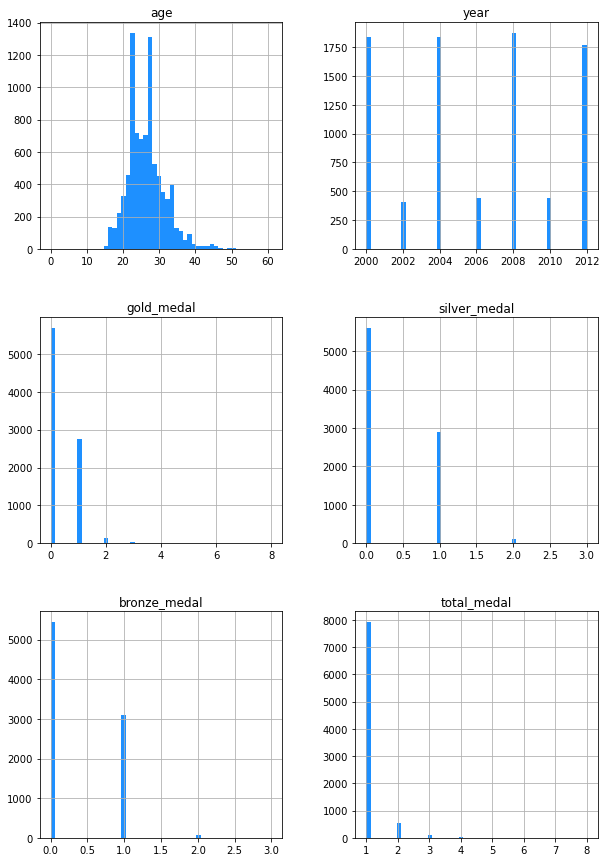

```python
%matplotlib inline
df.hist(bins=50, figsize=(10, 15),facecolor="dodgerblue")
plt.show()
```

### To check 'age' distribution of Participants

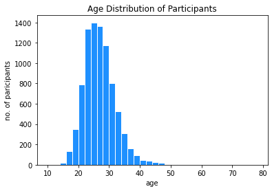

```python
plt.hist(df.age,bins=np.arange(10,80,2), edgecolor="white",facecolor="dodgerblue")
plt.xlabel("age")
plt.ylabel("no. of paricipants")
plt.title("Age Distribution of Participants")
plt.show()
```

### Performing appropriate Numerical Measures on each column

The describe() function generates summary of descriptive statistics for all the columns. It can analyze both numeric as ell as object type data.

### Applying describe() to numeric type data columns

For numeric data the, result’s index will include count, mean, std, min, max, IQR i.e. 25, 50, and 75 percentiles.

```python
df.describe()
```

|  | age | year | gold_medal | silver_medal | bronze_medal | total_medal |
| --- | --- | --- | --- | --- | --- | --- |
| count | 8615.000000 | 8615.000000 | 8615.000000 | 8615.000000 | 8615.000000 | 8615.000000 |
| mean | 26.399304 | 2005.976785 | 0.364829 | 0.363088 | 0.377829 | 1.105746 |
| std | 5.117364 | 4.289221 | 0.545401 | 0.511564 | 0.505044 | 0.408958 |
| min | 0.000000 | 2000.000000 | 0.000000 | 0.000000 | 0.000000 | 1.000000 |
| 25% | 23.000000 | 2002.000000 | 0.000000 | 0.000000 | 0.000000 | 1.000000 |
| 50% | 26.000000 | 2006.000000 | 0.000000 | 0.000000 | 0.000000 | 1.000000 |
| 75% | 29.000000 | 2010.000000 | 1.000000 | 1.000000 | 1.000000 | 1.000000 |
| max | 61.000000 | 2012.000000 | 8.000000 | 3.000000 | 3.000000 | 8.000000 |

Where,

**count** is the number of objects in the column.

**mean** is the mean value of the (numeric)column.

**std** is the Standard Deviation of values in the column.

**min** is the minimum value appearing in the column.

**25%** is the 25th percentile of values in the column.

**50%** is the 50th percentile of values in the column.

**75%** is the 75th percentile of values in the column.

**max** is the maximum value appearing in the column.

The result of df.describe() is self-explanatory. We can check various outcomes in the output.

### Applying describe() to object type data columns

For object data the result’s index will include count, unique, top, and freq.

```python
df.describe(include=object)
```

|  | name | country | Date_given | sports |
| --- | --- | --- | --- | --- |
| count | 8615 | 8615 | 8615 | 8615 |
| unique | 6958 | 110 | 7 | 49 |
| top | Matt Wells | United States | 24-08-2008 | Athletics |
| freq | 4 | 1109 | 1872 | 687 |

Where,

• **count** is the number of objects in the column.

• **unique** is the number of distinct object in the column.

• **top** is the Most frequently occurring object in the column.

• **freq** is te number of times the top appearing object in the column.

The result of df.describe(include=object) is self-explanatory. We can check various outcomes in the output.

### Exploring country column

We can check which country is having maximum participants in the over all years from 2000 to 2012.

```python
df.country.value_counts().sort_values(ascending=False).head(10)
```

```
United States    1109
Russia            706
Germany           552
Australia         524
China             450
Canada            351
Italy             307
Great Britain     296
France            287
Netherlands       286
Name: country, dtype: int64
```

The United States is highly participating in the Olympic Games. Also we have the top ten countries having highest participants.

### Exploring year column

We can find out years for which Olympic's data is given as bellow:

```python
df["year"].unique()
```

```
array([2008, 2004, 2012, 2000, 2006, 2010, 2002])
```

### Exploring country column

We will check sportsperson from India who is in our dataset.

```python
df_india = df.query('country == "India"')
df_india
```

|  | name | age | country | year | Date_given | sports | gold_medal | silver_medal | bronze_medal | total_medal |
| --- | --- | --- | --- | --- | --- | --- | --- | --- | --- | --- |
| 702 | Yogeshwar Dutt | 29 | India | 2012 | 12-08-2012 | Wrestling | 0 | 0 | 1 | 1 |
| 722 | Sushil Kumar | 29 | India | 2012 | 12-08-2012 | Wrestling | 0 | 1 | 0 | 1 |
| 797 | Sushil Kumar | 25 | India | 2008 | 24-08-2008 | Wrestling | 0 | 0 | 1 | 1 |
| 1094 | Karnam Malleswari | 25 | India | 2000 | 01-10-2000 | Weightlifting | 0 | 0 | 1 | 1 |
| 2786 | Vijay Kumar | 26 | India | 2012 | 12-08-2012 | Shooting | 0 | 1 | 0 | 1 |
| 2791 | Gagan Narang | 29 | India | 2012 | 12-08-2012 | Shooting | 0 | 0 | 1 | 1 |
| 2807 | Abhinav Bindra | 25 | India | 2008 | 24-08-2008 | Shooting | 1 | 0 | 0 | 1 |
| 2877 | Rajyavardhan Rathore | 34 | India | 2004 | 29-08-2004 | Shooting | 0 | 1 | 0 | 1 |
| 7170 | M. C. Mary Kom | 29 | India | 2012 | 12-08-2012 | Boxing | 0 | 0 | 1 | 1 |
| 7235 | Vijender Singh | 22 | India | 2008 | 24-08-2008 | Boxing | 0 | 0 | 1 | 1 |
| 7806 | Saina Nehwal | 22 | India | 2012 | 12-08-2012 | Badminton | 0 | 0 | 1 | 1 |

```python
df_india.name.count()
```

```
11
```

```python
df_india["year"].unique()
```

```
array([2012, 2008, 2000, 2004])
```

```python
df_india["sports"].unique()
```

```
array(['Wrestling', 'Weightlifting', 'Shooting', 'Boxing', 'Badminton'],
      dtype=object)
```

### Exploring sports column

We know there are 49 types of different sports are involved in the Olympics from describe() function. Now we will find out names of different types of sports played in Olympics as follows:

```python
df["sports"].unique()
```

```
array(['Swimming', 'Gymnastics', 'Speed Skating', 'Cross Country Skiing',
       'Short-Track Speed Skating', 'Diving', 'Cycling', 'Biathlon',
       'Alpine Skiing', 'Ski Jumping', 'Nordic Combined', 'Athletics',
       'Table Tennis', 'Tennis', 'Synchronized Swimming', 'Shooting',
       'Rowing', 'Fencing', 'Equestrian', 'Canoeing', 'Bobsleigh',
       'Badminton', 'Archery', 'Wrestling', 'Weightlifting', 'Waterpolo',
       'Volleyball', 'Triathlon', 'Trampoline', 'Taekwondo', 'Softball',
       'Snowboarding', 'Skeleton', 'Sailing', 'Rhythmic Gymnastics',
       'Modern Pentathlon', 'Luge', 'Judo', 'Ice Hockey', 'Hockey',
       'Handball', 'Football', 'Figure Skating', 'Freestyle Skiing',
       'Curling', 'Baseball', 'Boxing', 'Beach Volleyball', 'Basketball'],
      dtype=object)
```

```python
df.groupby("sports")["name"].unique().head(10)
```

```
sports
Alpine Skiing       [Janica Kostelic, Bode Miller, Aksel Lund Svin...
Archery             [Ki Bo-Bae, Oh Jin-Hyek, Park Gyeong-Mo, Park ...
Athletics           [Yohan Blake, Usain Bolt, Allyson Felix, Shell...
Badminton           [Zhao Yunlei, Lee Hyo-Jeong, Yu Yang, Gao Ling...
Baseball            [Brett Anderson, Jake Arrieta, Brian Barden, A...
Basketball          [Carmelo Anthony, Semyon Antonov, Seimone Augu...
Beach Volleyball    [Julius Brink, Alison Cerutti, Emanuel, Julian...
Biathlon            [Ole Einar BjÃ¸rndalen, Magdalena Neuner, Emil...
Bobsleigh           [Kevin Kuske, AndrÃ© Lange, Martin Annen, Beat...
Boxing              [Nicola Adams, Misha Aloyan, LÃ¡zaro Ãlvarez,...
Name: name, dtype: object
```

### Top 10 countries with the Gold Medal

```python
df_medals = df.groupby('country').sum()
gold_medals = df_medals.sort_values(by=['gold_medal'],ascending=False, inplace=False)
G = gold_medals[['gold_medal']].head(10)
G
```

| country | gold_medal |
| --- | --- |
| United States | 552 |
| Russia | 234 |
| China | 234 |
| Germany | 223 |
| Canada | 168 |
| Australia | 163 |
| Great Britain | 124 |
| South Korea | 110 |
| France | 108 |
| Netherlands | 101 |

### Visulization of the result using Barplot

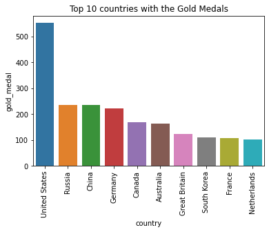

```python
plt.title("Top 10 countries with the Gold Medals")
sns.barplot(x = G.index, y="gold_medal", data=G)
plt.xticks(rotation=90)
plt.show()
```

## Top 10 countries with the Silver Medal

```python
silver_medals = df_medals.sort_values(by=['silver_medal'],ascending=False, inplace=False)
S = silver_medals[['silver_medal']].head(10)
S
```

| country | silver_medal |
| --- | --- |
| United States | 440 |
| Australia | 226 |
| Russia | 221 |
| Germany | 183 |
| China | 156 |
| Netherlands | 135 |
| Spain | 116 |
| Japan | 112 |
| France | 107 |
| Italy | 103 |

### Visulization of the result using Barplot

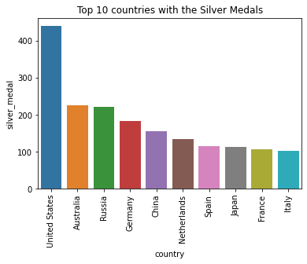

```python
plt.title("Top 10 countries with the Silver Medals")
sns.barplot(x = S.index, y="silver_medal", data=S)
plt.xticks(rotation=90)
plt.show()
```

```python
bronze_medals = df_medals.sort_values(by=['silver_medal'],ascending=False, inplace=False)
B = bronze_medals[['bronze_medal']].head(10)
B
```

| country | bronze_medal |
| --- | --- |
| United States | 320 |
| Australia | 220 |
| Russia | 313 |
| Germany | 223 |
| China | 140 |
| Netherlands | 82 |
| Spain | 70 |
| Japan | 113 |
| France | 103 |
| Italy | 142 |

### Visulization of the result using Barplot

[figure not shown]

```python
plt.title("Top 10 countries with the Bronze Medals")
sns.barplot(x = B.index, y="bronze_medal", data=B)
plt.xticks(rotation=90)
plt.show()
```

## Top 10 countries with the Total Medals

```python
total_medals = df_medals.sort_values(by=['total_medal'],ascending=False, inplace=False)
T = total_medals[['total_medal']].head(10)
T
```

| country | total_medal |
| --- | --- |
| United States | 1312 |
| Russia | 768 |
| Germany | 629 |
| Australia | 609 |
| China | 530 |
| Canada | 370 |
| Italy | 331 |
| Great Britain | 322 |
| France | 318 |
| Netherlands | 318 |

### Visulization of the result using Barplot

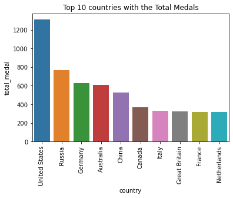

```python
plt.title("Top 10 countries with the Total Medals")
sns.barplot(x = T.index, y="total_medal", data=T)
plt.xticks(rotation=90)
plt.show()
```

## Representing top 10 countries having maximum total medals using pie chart

For easy visalization, finding out contribution of top 10 countries in percentage having sum of three medals i.e. gold, silver and bronze from year 2000 to 2012.

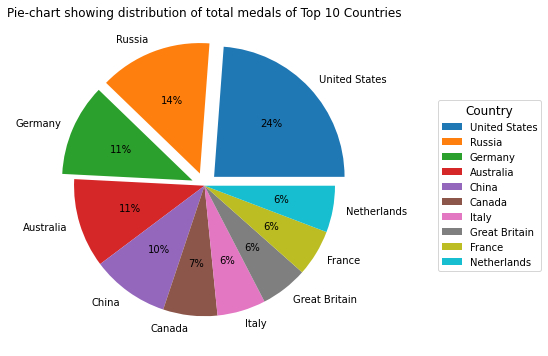

```python
my_explode=(0.1,0.1,0.1,0,0,0,0,0,0,0)
T.total_medal.plot(kind='pie', autopct='%.0f%%',explode=my_explode, label="",figsize=(6,6),legend=True)
plt.legend(title='Country',title_fontsize=12,loc='center left', bbox_to_anchor=(1.2, 0.5))
plt.title('Pie-chart showing distribution of total medals of Top 10 Countries')
plt.show()
```

### Conclusion

From the overall exploration of the data set, we can conclude as follows:

• Missing values and duplicate values didn't affect our exploration and findings, if handled properly.

• Average age of the athletes participated in the Olympics was 26 year.

• Total 49 sports were included for the year 2000-2012

• United States is having the highest number of total medals.

• Russia and Germany also showed good overall performance in the Olympics.

• India won 11 medals(1 Gold, 3 Silver and 7 Bronze) in the year 2000, 2004, 2008 and 2012.

• India won medals in 'Wrestling', 'Weightlifting', 'Shooting', 'Boxing', 'Badminton'

• Abhinav Bindra was the only Indian to win a Gold medal in the Olympic Games between 2000 and 2012.

## **SHUBH SHARMA 21013570096**